# Mouse prostate stroma clusters

Mindy Kim Graham

6/14/2021

# single cell analysis of mouse prostate (WT and Hi-MYC) at 6 months and 10 months subsetted to the stroma population

```r
# Libraries
library(Seurat)
```

```r
library(ggplot2)
library(sctransform)
library(glmGamPoi)
library(dplyr)
library(DataCombine)
library(viridis)
library(tidyverse)
# set working directory
wrkdir <- "C:/Users/mgraha21/OneDrive - Johns Hopkins/Mindy JHMI Onedrive/MYC prostate scRNAseq/Manuscript Version of Analysis/Github uploads" #update specific to user
setwd(wrkdir)
```

subset to stroma cells

```
# load intergrated seurat object
seurat.int <- readRDS(file = "FVB_DLP_int.rds")

Idents(seurat.int) <- "cell_type"
levels(seurat.int)

mouse_seurat_stroma <- subset(seurat.int, idents = c("Smooth Muscle", "Endothelial", "Fibroblasts", "Pericytes", "Mesenchymal Plp1"))
DimPlot(mouse_seurat_stroma)
```

integrate data by age https://satijalab.org/seurat/articles/sctransform_v2_vignette.html

```
# split the dataset into a list by strain (mo6 and mo10)
mouse_seurat_stroma.list <- SplitObject(mouse_seurat_stroma, split.by = "age")

mo6 <- mouse_seurat_stroma.list[["6mo"]]
mo10 <- mouse_seurat_stroma.list[["10mo"]]
```

Perform integration using pearson residuals

```
# normalize and run dimensionality reduction on mo10 libraries
mo10 <- SCTransform(mo10, vst.flavor = "v2", verbose = FALSE, return.only.var.genes = FALSE) %>%
    RunPCA(npcs = 30, verbose = FALSE)
mo6 <- SCTransform(mo6, vst.flavor = "v2", verbose = FALSE, return.only.var.genes = FALSE) %>%
    RunPCA(npcs = 30, verbose = FALSE)

mouse_seurat_stroma.list <- list(mo10 = mo10, mo6 = mo6)
features <- SelectIntegrationFeatures(object.list = mouse_seurat_stroma.list, nfeatures = 3000)
mouse_seurat_stroma.list <- PrepSCTIntegration(object.list = mouse_seurat_stroma.list, anchor.features = features)

# integrate datasets
age.anchors <- FindIntegrationAnchors(object.list = mouse_seurat_stroma.list, normalization.method = "SCT",
    anchor.features = features)
mouse_seurat_stroma <- IntegrateData(anchorset = age.anchors, normalization.method = "SCT")
```

Perform an integrated analysis

```
mouse_seurat_stroma <- RunPCA(mouse_seurat_stroma, verbose = FALSE)
mouse_seurat_stroma <- RunUMAP(mouse_seurat_stroma, reduction = "pca", dims = 1:30, verbose = FALSE)
mouse_seurat_stroma <- FindNeighbors(mouse_seurat_stroma, reduction = "pca", dims = 1:30)
mouse_seurat_stroma <- FindClusters(mouse_seurat_stroma, resolution = 0.2)

DimPlot(mouse_seurat_stroma, label = T, repel = T, shuffle = TRUE) + ggtitle("Unsupervised clustering")
DimPlot(mouse_seurat_stroma, label = T, repel = T, shuffle = TRUE, group.by = "age")
DimPlot(mouse_seurat_stroma, label = T, repel = T, shuffle = TRUE, group.by = "genotype")

table(mouse_seurat_stroma$stroma, mouse_seurat_stroma$integrated_snn_res.0.2)
```

SCT transform without integration Perform SCTransform for all genes, keeping integrating clustering dimensionality reduction by PCA and UMAP embedding https://satijalab.org/seurat/articles/sctransform_v2_vignette.html

```
library(glmGamPoi)

# run sctransform
mouse_seurat_stroma <- SCTransform(mouse_seurat_stroma, method = "glmGamPoi", verbose = FALSE, return.only.var.genes = FALSE, vst.flavor = "v2")
DimPlot(mouse_seurat_stroma, label = T, repel = T, shuffle = TRUE, group.by = "integrated_snn_res.0.2") + ggtitle("Unsupervised clustering")

table(mouse_seurat_stroma$integrated_snn_res.0.2, mouse_seurat_stroma$genotype_age)
```

stroma cell type markers, filtered for mixed clusters

```r
# subtype markers
sm_pericytes <- c("Tagln", "Acta2")
Smooth_Muscle <- c("Acta1", "Actg2")
Pericytes <- c("Rgs4", "Notch3")
Fibroblast <- c("Pdgfra", "Fbln1")
Fibroblast_subtypes <- c("Rorb", "Sult1e1", "Timp1")
Endothelial <- c("Flt1","Eng","Cdh5")
Glial <- c("Plp1", "Ngfr", "Mbp")
Epithelial <- c("Krt8", "Krt18")
```

```
gene_features <- c(Endothelial, Smooth_Muscle, sm_pericytes, Pericytes, Fibroblast, Fibroblast_subtypes, Glial)
DoHeatmap(subset(mouse_seurat_stroma, downsample = 100), features = c(gene_features)) +
  scale_fill_viridis()

# cluster 3 is an epithelial cell contaiminated cluster and will be filtered/removed from downstream analysis
table(mouse_seurat_stroma$cell_type, mouse_seurat_stroma$integrated_snn_res.0.2)

age.combined.filtered <- subset(mouse_seurat_stroma, idents = 3, invert = TRUE)
DimPlot(age.combined.filtered)
```

# integrate data by age using filtered seurat object

https://satijalab.org/seurat/articles/sctransform_v2_vignette.html

```
# split the dataset into a list by strain (mo6 and mo10)
mouse_seurat_stroma.list <- SplitObject(age.combined.filtered, split.by = "age")

mo6 <- mouse_seurat_stroma.list[["6mo"]]
mo10 <- mouse_seurat_stroma.list[["10mo"]]
```

Perform integration using pearson residuals

```
# normalize and run dimensionality reduction on mo10 libraries
mo10 <- SCTransform(mo10, vst.flavor = "v2", verbose = FALSE, return.only.var.genes = FALSE) %>%
    RunPCA(npcs = 30, verbose = FALSE)
mo6 <- SCTransform(mo6, vst.flavor = "v2", verbose = FALSE, return.only.var.genes = FALSE) %>%
    RunPCA(npcs = 30, verbose = FALSE)

mouse_seurat_stroma.list <- list(mo10 = mo10, mo6 = mo6)
features <- SelectIntegrationFeatures(object.list = mouse_seurat_stroma.list, nfeatures = 3000)
mouse_seurat_stroma.list <- PrepSCTIntegration(object.list = mouse_seurat_stroma.list, anchor.features = features)

# integrate datasets
age.anchors <- FindIntegrationAnchors(object.list = mouse_seurat_stroma.list, normalization.method = "SCT",
    anchor.features = features)
mouse_seurat_stroma <- IntegrateData(anchorset = age.anchors, normalization.method = "SCT")
```

Perform an integrated analysis

```
mouse_seurat_stroma <- RunPCA(mouse_seurat_stroma, verbose = FALSE)
mouse_seurat_stroma <- RunUMAP(mouse_seurat_stroma, reduction = "pca", dims = 1:30, verbose = FALSE)
mouse_seurat_stroma <- FindNeighbors(mouse_seurat_stroma, reduction = "pca", dims = 1:30)
mouse_seurat_stroma <- FindClusters(mouse_seurat_stroma, resolution = 0.1)

DimPlot(mouse_seurat_stroma, label = T, repel = T, shuffle = TRUE) + ggtitle("Unsupervised clustering")
DimPlot(mouse_seurat_stroma, label = F, repel = T, shuffle = TRUE, group.by = "age")
DimPlot(mouse_seurat_stroma, label = F, repel = T, shuffle = TRUE, group.by = "genotype")

table(mouse_seurat_stroma$stroma, mouse_seurat_stroma$integrated_snn_res.0.1)
table(mouse_seurat_stroma$genotype_age, mouse_seurat_stroma$integrated_snn_res.0.1)
```

SCT transform without integration Perform SCTransform for all genes, keeping integrating clustering dimensionality reduction by PCA and UMAP embedding https://satijalab.org/seurat/articles/sctransform_v2_vignette.html

```
library(glmGamPoi)

# run sctransform
mouse_seurat_stroma <- SCTransform(mouse_seurat_stroma, method = "glmGamPoi", verbose = FALSE, return.only.var.genes = FALSE, vst.flavor = "v2")
DimPlot(mouse_seurat_stroma, label = T, repel = T, shuffle = TRUE, group.by = "integrated_snn_res.0.1") + ggtitle("Unsupervised clustering")
```

Differential gene expression of clusters

```
# differentially expressed genes for each cluster
levels(mouse_seurat_stroma)
stroma_clusters <- FindAllMarkers(mouse_seurat_stroma)

saveRDS(stroma_clusters, file = "mouse_seurat_stroma_DGE.rds")
write.csv(stroma_clusters, file = "mouse_seurat_stroma_DGE.csv")

# cluster genes
stroma_clusters <- readRDS(file = "mouse_seurat_stroma_DGE.rds")
top_stroma <- stroma_clusters %>% group_by(cluster) %>% filter(avg_log2FC > 0, pct.2 < 0.3) %>% top_n(5, -p_val_adj) %>% top_n(10, avg_log2FC)

FibTimp1 <- top_stroma %>% filter(cluster %in% "Fibroblasts Timp1")
subset(mouse_seurat_stroma, idents = c("Fibroblasts Subglandular", "Fibroblasts Interstitial", "Fibroblasts Timp1") ) %>%
  VlnPlot(features = c(FibTimp1$gene), group.by = "genotype_age", stack = TRUE, flip = TRUE) +
  NoLegend() + ggtitle("Fibroblasts") +
  theme(plot.title = element_text(hjust = 0.5))

DoHeatmap(subset(mouse_seurat_stroma, downsample = 100), features = c(top_stroma$gene)) +
  scale_fill_viridis()
```

name clusters 0 - Endothelial 1 - Fibroblasts Timp1 2 - Fibroblasts Subglandular 3 - Fibroblasts Interstitial 4 - Pericytes 5 - Smooth Muscle 6 - Glial

```
# stroma cells ID
Idents(mouse_seurat_stroma) <- "integrated_snn_res.0.1"
new.cluster.ids <- c("Endothelial",
                     "Fibroblasts Timp1", "Fibroblasts Subglandular", "Fibroblasts Interstitial", "Pericytes", "Smooth Muscle",
                     "Glial")

names(new.cluster.ids) <- levels(mouse_seurat_stroma)
mouse_seurat_stroma[["stroma"]] <- new.cluster.ids[as.numeric(as.matrix(mouse_seurat_stroma@meta.data$integrated_snn_res.0.1))+1]
mouse_seurat_stroma <- RenameIdents(mouse_seurat_stroma, new.cluster.ids)
```

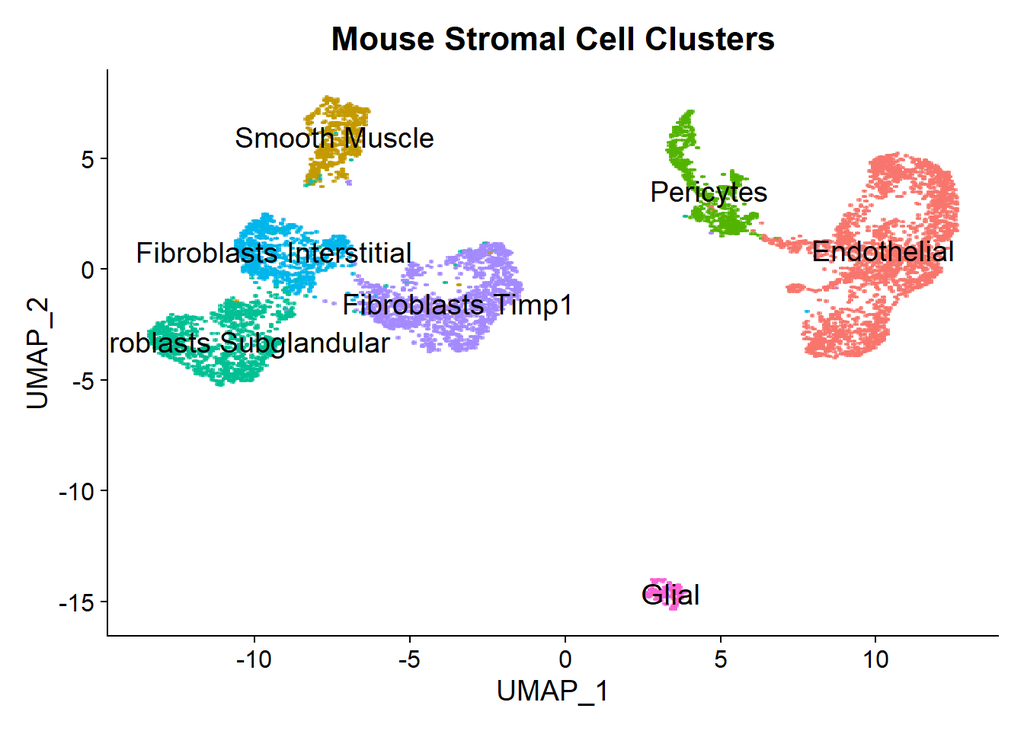

```r
library(wesanderson)
pal <- wes_palette("Zissou1", 6, type = "continuous")

mouse_seurat_stroma <- readRDS(file = "seurat_stroma.rds")

Idents(mouse_seurat_stroma) <- "stroma"
levels(mouse_seurat_stroma) <- c("Endothelial", "Smooth Muscle", "Pericytes",
                        "Fibroblasts Subglandular", "Fibroblasts Interstitial", "Fibroblasts Timp1",
                        "Glial")

DimPlot(mouse_seurat_stroma, label = TRUE, raster = TRUE, label.size = 5, pt.size = 2) + NoLegend() + ggtitle("Mouse Stromal Cell Clusters")+
  theme(plot.title = element_text(hjust = 0.5))
```

[figure not shown]

```r
DimPlot(mouse_seurat_stroma, label = FALSE, group.by = "age", raster = TRUE,
                 label.size = 5, cols = c("#f6bd60", "#84a59d"), pt.size =2) +
  ggtitle("Age")+ theme(plot.title = element_text(hjust = 0.5))
```

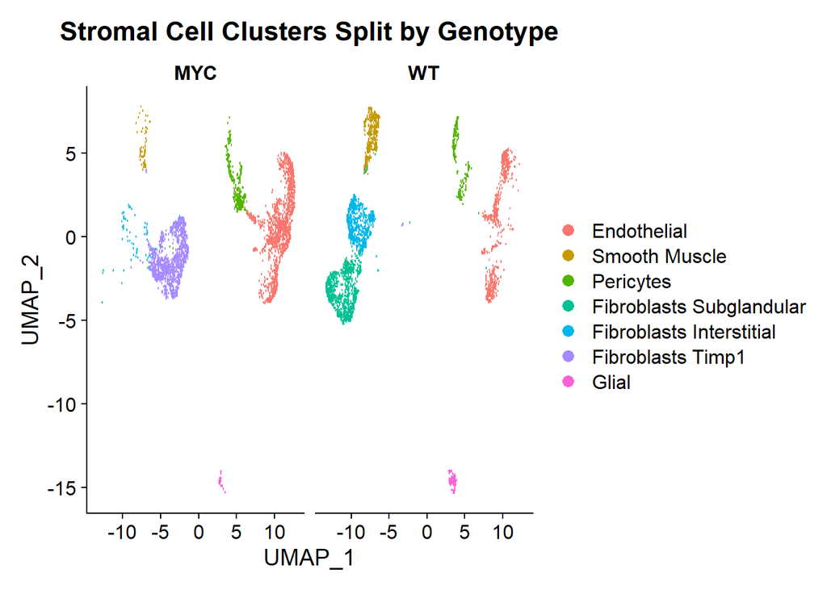

```r
DimPlot(mouse_seurat_stroma, label = FALSE, raster = TRUE, label.size = 5, split.by = "genotype", pt.size = 2) + ggtitle("Stromal Cell Clusters Split by Genotype")+
  theme(plot.title = element_text(hjust = 0.5))
```

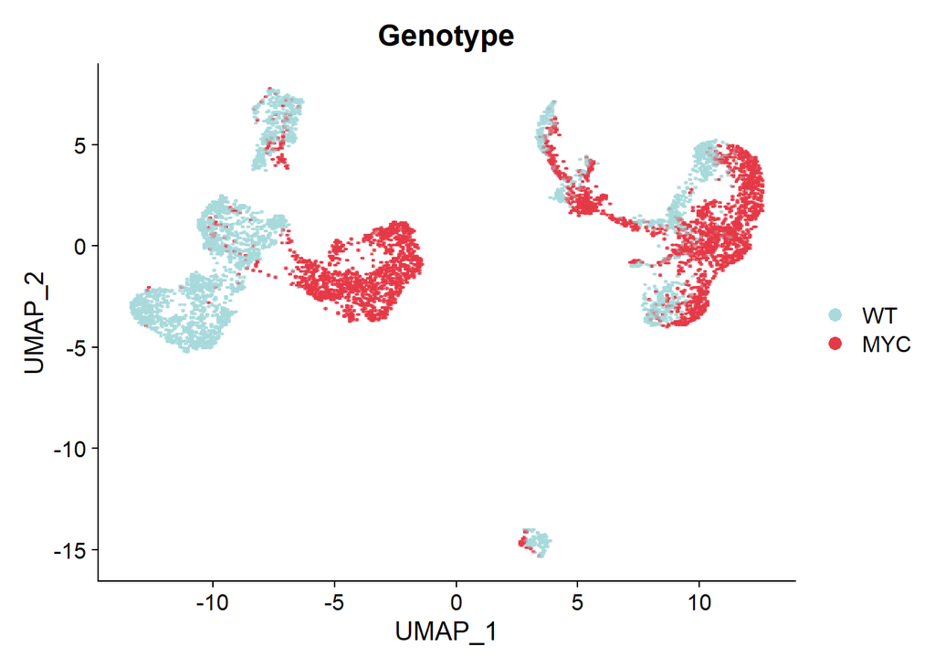

```r
mouse_seurat_stroma$genotype <- factor(mouse_seurat_stroma$genotype, levels = c("WT", "MYC"))

DimPlot(mouse_seurat_stroma, label = FALSE, group.by = "genotype", raster = TRUE, label.size = 5, cols = c("#a8dadc", "#e63946"), pt.size = 2) +
  ggtitle("Genotype")+ theme(plot.title = element_text(hjust = 0.5))
```

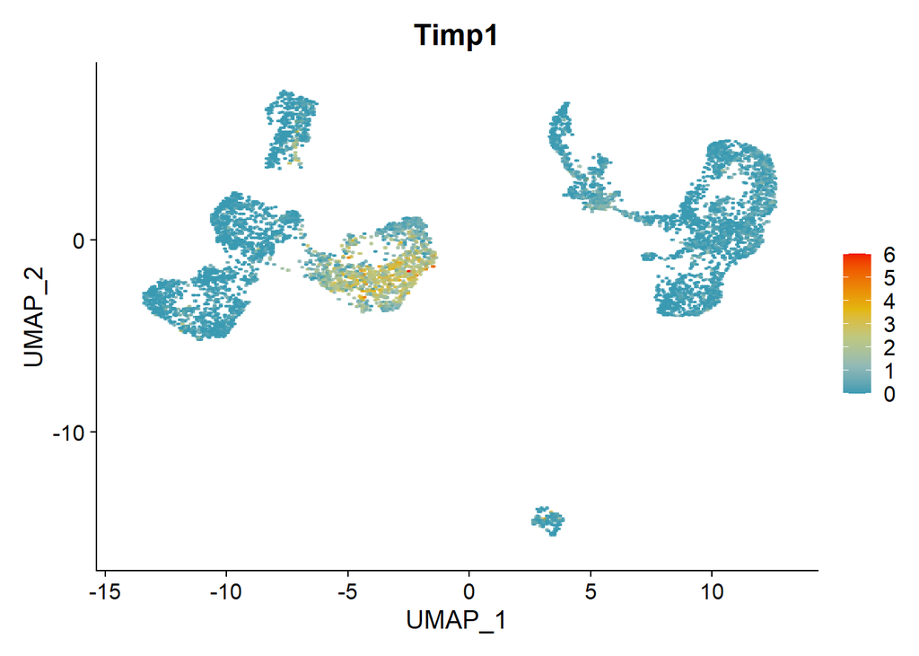

```r
FeaturePlot(mouse_seurat_stroma, features = "Timp1", raster = TRUE, order = TRUE, pt.size = 2) + scale_color_gradientn(colours = pal)
```

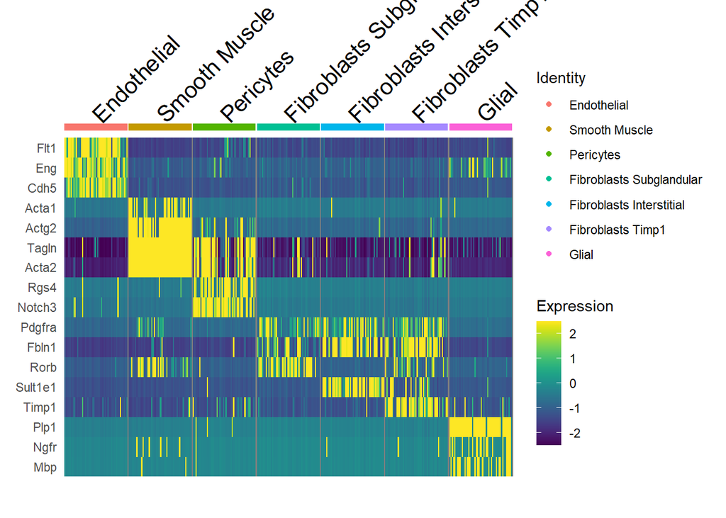

```r
# heatmap of stromal marker genes
gene_features <- c(Endothelial, Smooth_Muscle, sm_pericytes, Pericytes, Fibroblast, Fibroblast_subtypes, Glial)
DoHeatmap(subset(mouse_seurat_stroma, downsample = 50), features = c(gene_features)) +
  scale_fill_viridis()
```

# Cell proportions by RAISIN

Update stroma cell types in seurat.int

```
# stroma clusters
Idents(seurat.int) <- "cell_type"
DimPlot(seurat.int)

seurat.int$stroma <- seurat.int$cell_type
seurat.int$stroma <- gsub("Smooth Muscle", "", seurat.int$stroma)
seurat.int$stroma <- gsub("Endothelial", "", seurat.int$stroma)
seurat.int$stroma <- gsub("Fibroblasts", "", seurat.int$stroma)
seurat.int$stroma <- gsub("Pericytes", "", seurat.int$stroma)
seurat.int$stroma <- gsub("Glial", "", seurat.int$stroma)
table(seurat.int$stroma)

seurat.int$stroma_subset <- mouse_seurat_stroma$stroma
seurat.int$stroma <- paste0(seurat.int$stroma_subset, seurat.int$stroma)
table(seurat.int$stroma)
seurat.int$stroma <- gsub("NA", "", seurat.int$stroma)

table(seurat.int$stroma)
saveRDS(seurat.int, file = "FVB_DLP_int.rds")
```

RAISIN https://github.com/zji90/raisin// cell proportion by genotype

```r
library(raisin)

# load complete seurat object
seurat.int <- readRDS(file = "FVB_DLP_int.rds")

# extract metadata from seurat object
Idents(seurat.int) <- "stroma"
levels(seurat.int)
```

```
##  [1] "Basal"                    "Luminal"
##  [3] "Smooth Muscle"            "Luminal MYC 1"
##  [5] "Ionocytes"                "Luminal Psca"
##  [7] "Mast cells"               "Macrophages"
##  [9] "Endothelial"              "Fibroblasts Subglandular"
## [11] "Pericytes"                "Fibroblasts Interstitial"
## [13] ""                         "T cells"
## [15] "Glial"                    "Fibroblasts Timp1"
```

```r
cluster <- Idents(seurat.int)

Idents(seurat.int) <- "orig.ident"
levels(seurat.int)
```

```
##  [1] "WT_D6_1"    "WT_D6_2"    "WT_L6_1"    "WT_L6_2"    "HiMYC_D6_1"
##  [6] "HiMYC_D6_2" "HiMYC_L6_1" "HiMYC_L6_2" "WT_B9_1"    "WT_B9_2"
## [11] "HiMYC_B9_1" "HiMYC_B9_2"
```

```r
individual <- Idents(seurat.int)

# make the design
design <- data.frame(intercept=1,contrast=c(1,1,1,1,
                                            1,1,
                                            0,0,0,0,
                                            0,0),
                     row.names = c("HiMYC_D6_1", "HiMYC_D6_2", "HiMYC_L6_1", "HiMYC_L6_2",
                                   "HiMYC_B9_1", "HiMYC_B9_2",
                                   "WT_D6_1", "WT_D6_2", "WT_L6_1", "WT_L6_2",
                                   "WT_B9_1", "WT_B9_2"))

# run the test
prop_test_results <- proportiontest(cluster,individual,design)
prop_test_results <- prop_test_results %>% tibble::rownames_to_column("Cluster")
prop_test_results
```

```
##                     Cluster      logFC      P.Value    adj.P.Val
## 1         Fibroblasts Timp1  5.7029233 4.304834e-12 6.887735e-11
## 2                 Ionocytes -4.1797069 8.797821e-09 7.038257e-08
## 3                   Luminal -2.6709697 1.713273e-07 9.137456e-07
## 4             Luminal MYC 1  1.8750373 1.027992e-05 4.111968e-05
## 5               Macrophages  1.7898866 1.184739e-04 3.791164e-04
## 6  Fibroblasts Subglandular -3.3302224 3.429256e-04 9.144681e-04
## 7                Mast cells  2.1820276 6.095440e-04 1.367676e-03
## 8             Smooth Muscle -1.9692501 6.838378e-04 1.367676e-03
## 9              Luminal Psca  1.1622718 8.661611e-04 1.539842e-03
## 10 Fibroblasts Interstitial -3.0413636 2.103660e-03 3.365856e-03
## 11              Endothelial  1.2921181 2.678952e-03 3.896658e-03
## 12                    Basal -0.4828808 4.985957e-02 6.647943e-02
## 13                  T cells  1.0316719 3.616123e-01 4.450613e-01
## 14                          -0.2856724 4.651447e-01 5.315940e-01
## 15                Pericytes  0.1316908 7.666441e-01 8.177537e-01
## 16                    Glial  0.1925077 8.349132e-01 8.349132e-01
```

Plot cell proportion diferences of stroma cells

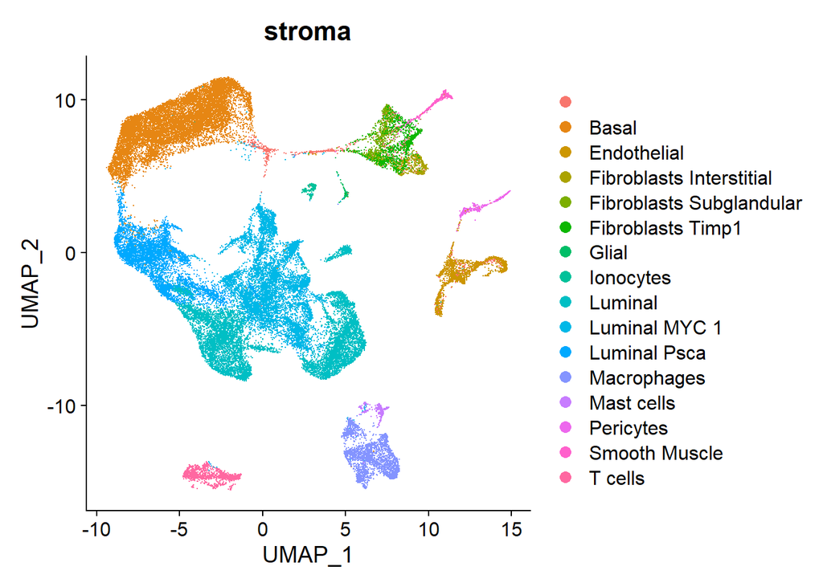

```r
DimPlot(seurat.int, group.by = "stroma")
```

```r
table(seurat.int$stroma)
```

```
##
##                                             Basal              Endothelial
##                      734                    12181                     2095
## Fibroblasts Interstitial Fibroblasts Subglandular        Fibroblasts Timp1
##                      703                      957                     1217
##                    Glial                Ionocytes                  Luminal
##                      158                      253                     9324
##            Luminal MYC 1             Luminal Psca              Macrophages
##                     8883                     5318                     2739
##               Mast cells                Pericytes            Smooth Muscle
##                      359                      590                      442
##                  T cells
##                     1376
```

```r
library(ggpubr)
library_counts <- as.data.frame(table(seurat.int$orig.ident))

# create dataframe containing all relevant metadata
cell_type_enrich <- as.data.frame(table(seurat.int$orig.ident,seurat.int$genotype, seurat.int$age, seurat.int$stroma))

cell_type_enrich$library <- library_counts$Freq
cell_type_enrich$fraction <- cell_type_enrich$Freq / cell_type_enrich$library

# rename columns to meaningful column names
colnames(cell_type_enrich) <- c("Library", "Genotype", "Age", "Cluster", "Counts", "Library_Counts", "Fraction")

# filter to library
Idents(seurat.int) <- "orig.ident"
levels(seurat.int)
```

```
##  [1] "WT_D6_1"    "WT_D6_2"    "WT_L6_1"    "WT_L6_2"    "HiMYC_D6_1"
##  [6] "HiMYC_D6_2" "HiMYC_L6_1" "HiMYC_L6_2" "WT_B9_1"    "WT_B9_2"
## [11] "HiMYC_B9_1" "HiMYC_B9_2"
```

```r
WT_D6_1 <- cell_type_enrich %>% filter(Library == "WT_D6_1", Genotype == "WT", Age == "6mo")
WT_D6_2 <- cell_type_enrich %>% filter(Library == "WT_D6_2", Genotype == "WT", Age == "6mo")
WT_L6_1 <- cell_type_enrich %>% filter(Library == "WT_L6_1", Genotype == "WT", Age == "6mo")
WT_L6_2 <- cell_type_enrich %>% filter(Library == "WT_L6_2", Genotype == "WT", Age == "6mo")

HiMYC_D6_1 <- cell_type_enrich %>% filter(Library == "HiMYC_D6_1", Genotype == "MYC", Age == "6mo")
HiMYC_D6_2 <- cell_type_enrich %>% filter(Library == "HiMYC_D6_2", Genotype == "MYC", Age == "6mo")
HiMYC_L6_1 <- cell_type_enrich %>% filter(Library == "HiMYC_L6_1", Genotype == "MYC", Age == "6mo")
HiMYC_L6_2 <- cell_type_enrich %>% filter(Library == "HiMYC_L6_2", Genotype == "MYC", Age == "6mo")

WT_B9_1 <- cell_type_enrich %>% filter(Library == "WT_B9_1", Genotype == "WT", Age == "10mo")
WT_B9_2 <- cell_type_enrich %>% filter(Library == "WT_B9_2", Genotype == "WT", Age == "10mo")
HiMYC_B9_1 <- cell_type_enrich %>% filter(Library == "HiMYC_B9_1", Genotype == "MYC", Age == "10mo")
HiMYC_B9_2 <- cell_type_enrich %>% filter(Library == "HiMYC_B9_2", Genotype == "MYC", Age == "10mo")

filtered_library_fraction <- rbind(WT_D6_1, WT_D6_2, WT_L6_1, WT_L6_2,
                                   HiMYC_D6_1, HiMYC_D6_2, HiMYC_L6_1, HiMYC_L6_2,
                                   WT_B9_1, WT_B9_2, HiMYC_B9_1, HiMYC_B9_2)

# combine DF with cell proportion test results
combined_df <- merge(filtered_library_fraction, prop_test_results, by.x = "Cluster", by.y = "Cluster")
combined_df$`Genotype Age` <- paste(combined_df$Genotype, combined_df$Age, sep = " ")

# Add pvalue to cluster name
library(scales)
combined_df$cluster_adjP <- paste(combined_df$Cluster,
                                  "\n Hi-Myc vs WT",
                                  "\n logFC = ",
                                  signif(combined_df$logFC, 2),
                                  ", adj p-value = ", scientific(combined_df$adj.P.Val, 1))


# update level names
combined_df$`Genotype Age` <- gsub(" ", "\n", combined_df$`Genotype Age`)

# order x axis
combined_df$`Genotype Age` <- factor(combined_df$`Genotype Age`, levels = c("WT\n6mo", "WT\n10mo", "MYC\n6mo", "MYC\n10mo"))
levels(combined_df$`Genotype Age`)
```

```
## [1] "WT\n6mo"   "WT\n10mo"  "MYC\n6mo"  "MYC\n10mo"
```

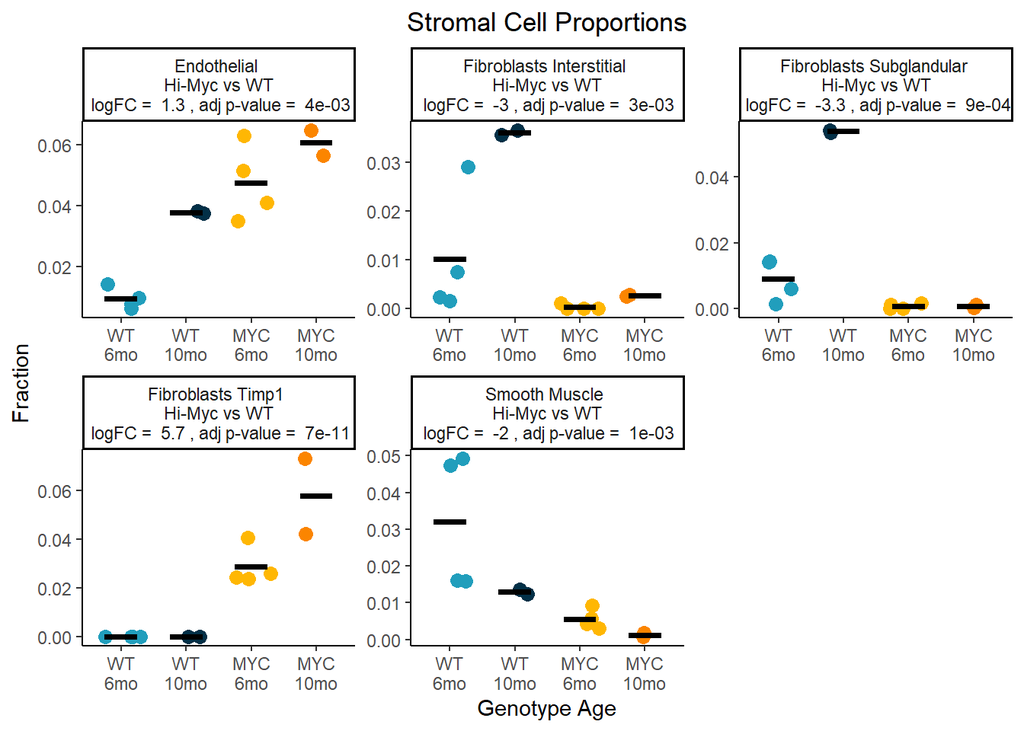

```r
# save df
# saveRDS(combined_df, file = "stroma_combined_df.rds")

# Plot selected stroma cells
fib_prop <- combined_df %>%
  filter(Cluster %in% c("Endothelial", "Smooth Muscle", "Fibroblasts Subglandular", "Fibroblasts Interstitial", "Fibroblasts Timp1" )) %>%
  ggplot(aes(x = `Genotype Age`, y = Fraction))+
  geom_jitter(aes(fill = Genotype, color = `Genotype Age`), size = 3,
              width = 0.3) +
  theme_classic() +
  stat_summary(fun = mean, fun.min = mean, fun.max = mean,
               geom = "crossbar", width = 0.5) +
  ggtitle("Stromal Cell Proportions") +
  theme(plot.title = element_text(hjust = 0.5))+
  facet_wrap(~cluster_adjP, scales = "free", ncol = 3) +
  scale_color_manual(values = c("#219ebc", "#023047", "#ffb703", "#fb8500")) +
  NoLegend()

fib_prop
```

```r
# VlnPlot
Idents(seurat.int) <- "stroma"
levels(seurat.int)
```

```
##  [1] "Basal"                    "Luminal"
##  [3] "Smooth Muscle"            "Luminal MYC 1"
##  [5] "Ionocytes"                "Luminal Psca"
##  [7] "Mast cells"               "Macrophages"
##  [9] "Endothelial"              "Fibroblasts Subglandular"
## [11] "Pericytes"                "Fibroblasts Interstitial"
## [13] ""                         "T cells"
## [15] "Glial"                    "Fibroblasts Timp1"
```

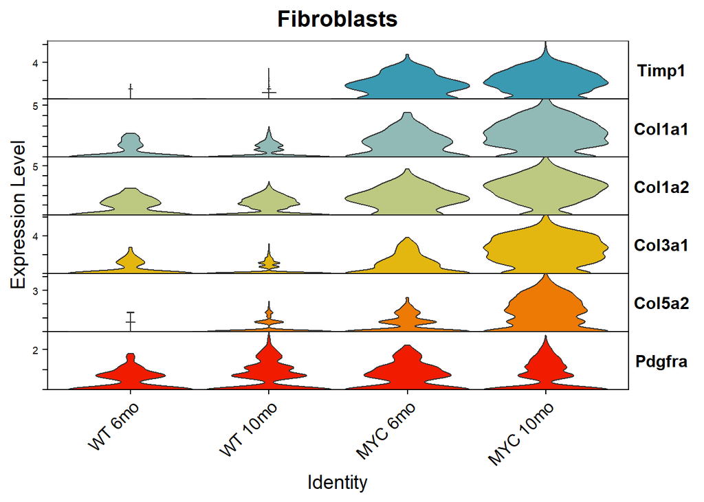

```r
seurat.int$genotype_age <- paste(seurat.int$genotype, seurat.int$age, sep = " ")
seurat.int$genotype_age <- factor(seurat.int$genotype_age, levels = c("WT 6mo", "WT 10mo", "MYC 6mo", "MYC 10mo"))
plot_fib <-
subset(seurat.int, idents = c("Fibroblasts Subglandular", "Fibroblasts Interstitial", "Fibroblasts Timp1") ) %>%
  VlnPlot(features = c("Timp1", "Col1a1", "Col1a2", "Col3a1", "Col5a2", "Pdgfra"), group.by = "genotype_age", stack = TRUE, flip = TRUE) +
  scale_fill_manual(values = pal) +
  NoLegend() + ggtitle("Fibroblasts") +
  theme(plot.title = element_text(hjust = 0.5))
plot_fib
```

Save seurat object

```
saveRDS(mouse_seurat_stroma, file = "mouse_seurat_stroma.rds")
```

# CAF marker genes

Examine the Timp1 Fibroblast cluster for previously published CAF molecular markers and subtypes https://aacrjournals.org/clincancerres/article/27/9/2636/672059/Molecular-Features-of-Cancer-associated-Fibroblast https://www.r-bloggers.com/2016/10/converting-mouse-to-human-gene-names-with-biomart-package/ https://carmonalab.github.io/UCell_demo/UCell_Seurat_vignette.html

```
# functions to convert mouse and human genes
mouse_human_genes = read.csv("http://www.informatics.jax.org/downloads/reports/HOM_MouseHumanSequence.rpt",sep="\t")

convert_mouse_to_human <- function(gene_list){

  output = c()

  for(gene in gene_list){
    class_key = (mouse_human_genes %>% filter(Symbol == gene & Common.Organism.Name=="mouse, laboratory"))[['DB.Class.Key']]
    if(!identical(class_key, integer(0)) ){
      human_genes = (mouse_human_genes %>% filter(DB.Class.Key == class_key & Common.Organism.Name=="human"))[,"Symbol"]
      for(human_gene in human_genes){
        output = append(output,human_gene)
      }
    }
  }

  return (output)
}

convert_human_to_mouse <- function(gene_list){

  output = c()

  for(gene in gene_list){
    class_key = (mouse_human_genes %>% filter(Symbol == gene & Common.Organism.Name=="human"))[['DB.Class.Key']]
    if(!identical(class_key, integer(0)) ){
      human_genes = (mouse_human_genes %>% filter(DB.Class.Key == class_key & Common.Organism.Name=="mouse, laboratory"))[,"Symbol"]
      for(human_gene in human_genes){
        output = append(output,human_gene)
      }
    }
  }

  return (output)
}

# import panCAF marker genes and generate genesignature list
library(readxl)
panCAF <- read_excel("Galbo_CAF_markers.xlsx",
    sheet = "Table S3", skip = 1)

pan_myCAF <- panCAF$`pan-myCAF` %>% na.omit()
pan_dCAF <- panCAF$`pan-dCAF` %>% na.omit()
pan_iCAF <- panCAF$`pan-iCAF` %>% na.omit()
pan_iCAF2 <- panCAF$`pan-iCAF-2` %>% na.omit()
pan_pCAF <- panCAF$`pan-pCAF` %>% na.omit()

# convert human to mouse genes
ms_pan_myCAF <- convertHumanGeneList(pan_myCAF)
ms_pan_dCAF <- convertHumanGeneList(pan_dCAF)
ms_pan_iCAF <- convertHumanGeneList(pan_iCAF)
ms_pan_iCAF2 <- convertHumanGeneList(pan_iCAF2)
ms_pan_pCAF <- convertHumanGeneList(pan_pCAF)

# generate gene signature lists
genelist <- list()
genelist$pan_myCAF <- ms_pan_myCAF
genelist$pan_dCAF <- ms_pan_dCAF
genelist$pan_iCAF <- ms_pan_iCAF
genelist$pan_iCAF2 <- ms_pan_iCAF2
genelist$pan_pCAF <- ms_pan_pCAF

saveRDS(genelist, file = "CAF_genelist.rds")
```

```r
# gene signature analysis
library(UCell)
library(wesanderson)
pal5 <- wes_palette("Zissou1", 5, "continuous")

# load mouse converted CAF genelist
genelist <- readRDS(file = "CAF_genelist.rds")

mouse_seurat_stroma <- AddModuleScore_UCell(mouse_seurat_stroma, features = genelist)
```

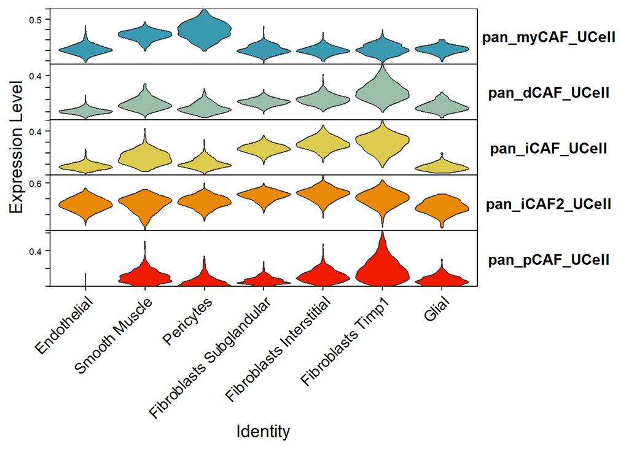

```r
signature.names <- paste0(names(genelist), "_UCell")

# vlnplot
levels(mouse_seurat_stroma) <- levels(mouse_seurat_stroma)
VlnPlot(mouse_seurat_stroma, features = signature.names, stack = TRUE, flip = TRUE, cols = pal5) + NoLegend()
```

# heatmap at single cell level of CAF scores Fibroblast clusters

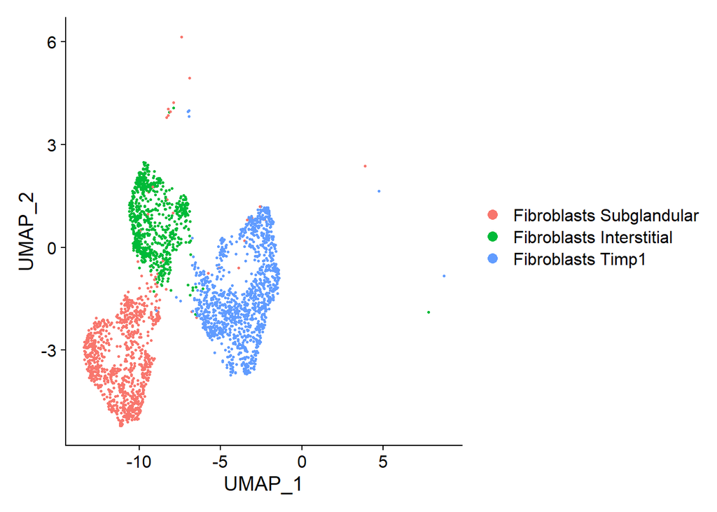

```r
# complex heatmap
library(tidyverse)
library(RColorBrewer)
library(ComplexHeatmap)
fibroblast_seurat <- subset(mouse_seurat_stroma, idents = c("Fibroblasts Timp1", "Fibroblasts Subglandular", "Fibroblasts Interstitial"))
DimPlot(fibroblast_seurat)
```

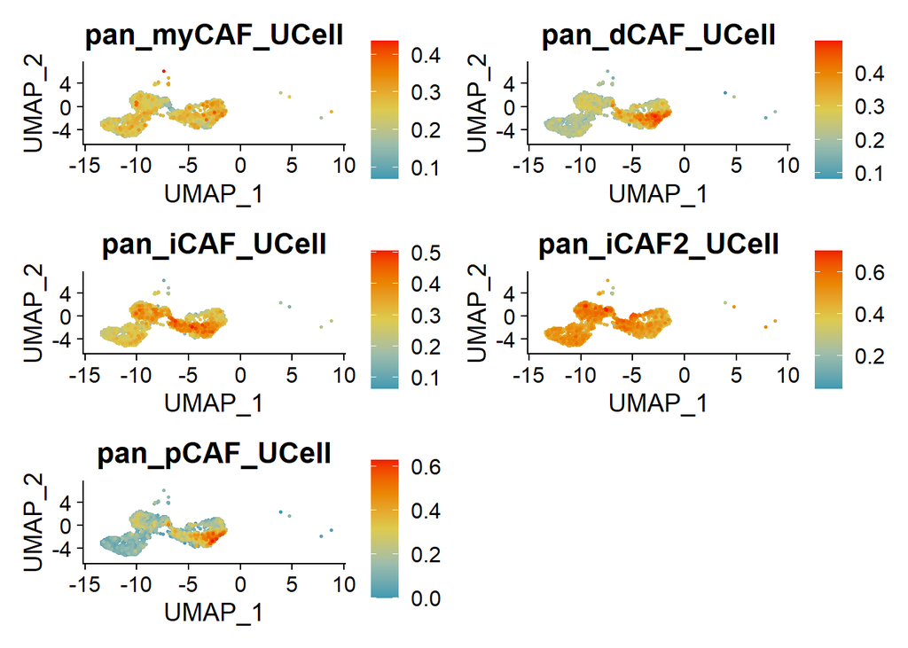

```r
FeaturePlot(fibroblast_seurat, features = signature.names, order = TRUE) & scale_color_gradientn(colors = pal5)
```

```r
gene_sig_df <- fibroblast_seurat@meta.data[c(18, 23:27)]

gene_sig_matrix <- gene_sig_df[2:6] %>% as.matrix()

# row standardization
AvgExp_scale <- t(apply(gene_sig_matrix, 1, scale))
colnames(AvgExp_scale) <- colnames(gene_sig_matrix)
```

annotations

```r
annotations <- gene_sig_df[1]
head(annotations)
```

```
##                                      stroma
## AAACGAAAGCACCCAC_9 Fibroblasts Subglandular
## AAACGAATCGACATTG_9 Fibroblasts Subglandular
## AAAGAACAGCCTTGAT_9 Fibroblasts Subglandular
## AAAGAACCAGGGAGAG_9 Fibroblasts Interstitial
## AAAGGGCCAGGTTACT_9 Fibroblasts Interstitial
## AAAGGGCGTATTAAGG_9 Fibroblasts Interstitial
```

```r
# Annotations to be added to the top of the heatmap
top.annotations = HeatmapAnnotation(`Fibroblast Cluster` = gene_sig_df$stroma,
    col = list(`Fibroblast Cluster` = c("Fibroblasts Subglandular" = "#3B9AB2",
                   "Fibroblasts Interstitial" = "#EBCC2A",
                   "Fibroblasts Timp1" = "#F21A00")),
    which = "row")
```

heatmap of gene signature scores

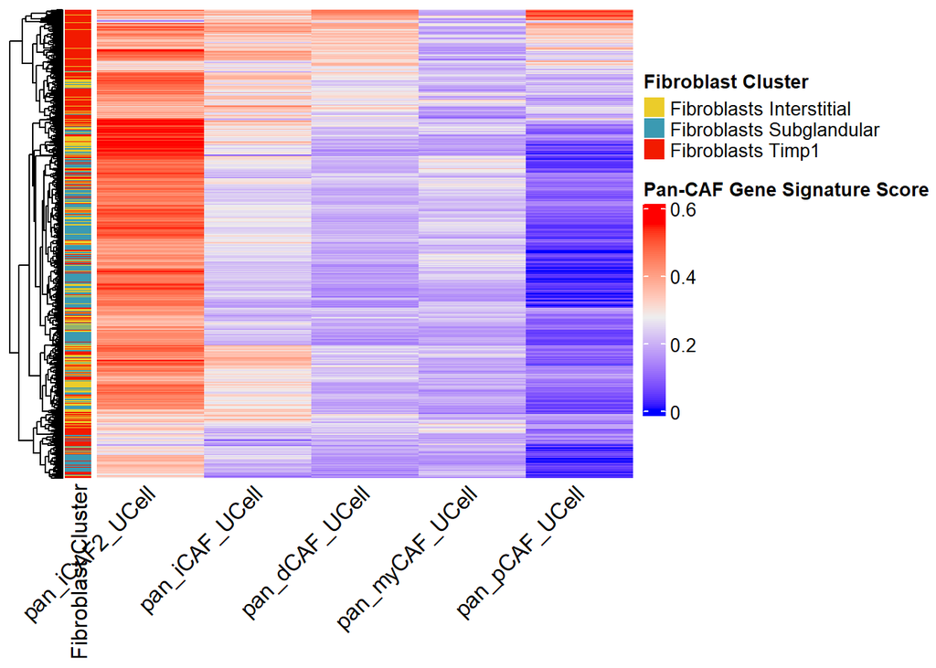

```r
# complex heatmap
Heatmap(gene_sig_matrix,
        left_annotation = top.annotations,
        column_dend_reorder = TRUE,
        row_dend_reorder = TRUE,
        show_row_dend = TRUE,
        show_column_dend = FALSE,
        show_row_names = FALSE,
        show_column_names = TRUE,
        row_names_gp = gpar(fontsize = 12),
       column_names_rot = 45,
       heatmap_legend_param = list(
    title = "Pan-CAF Gene Signature Score",
    legend_height = unit(4, "cm")
))
```

UMAPs

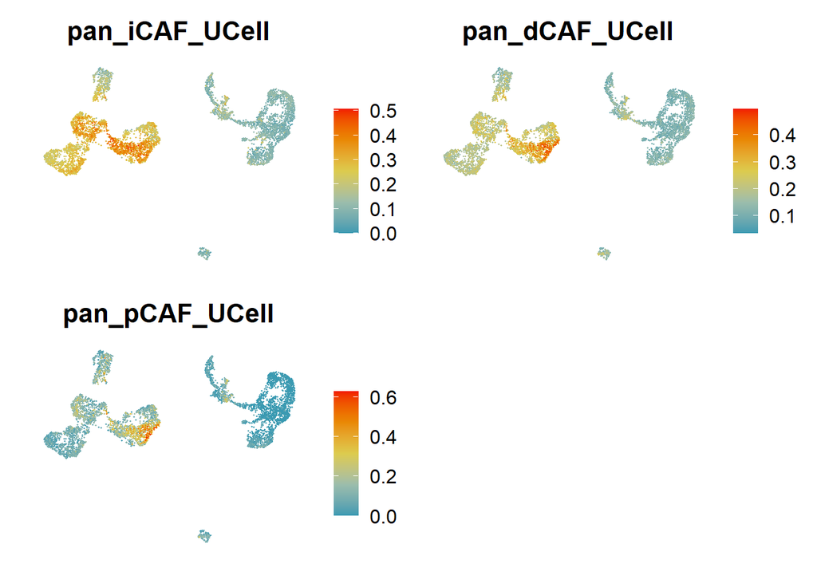

```r
FeaturePlot(mouse_seurat_stroma, features = c("pan_iCAF_UCell", "pan_dCAF_UCell", "pan_pCAF_UCell"), order = TRUE) & scale_color_gradientn(colors = pal5) & NoAxes()
```

```r
iCAF <- WhichCells(mouse_seurat_stroma, expression = pan_iCAF_UCell > 0.3)
mouse_seurat_stroma$pan_iCAF <- ifelse(colnames(mouse_seurat_stroma) %in% iCAF, "Pan-iCAF", "Low")

dCAF <- WhichCells(mouse_seurat_stroma, expression = pan_dCAF_UCell > 0.3)
mouse_seurat_stroma$pan_dCAF <- ifelse(colnames(mouse_seurat_stroma) %in% dCAF, "Pan-dCAF", "Low")

pCAF <- WhichCells(mouse_seurat_stroma, expression = pan_pCAF_UCell > 0.3)
mouse_seurat_stroma$pan_pCAF <- ifelse(colnames(mouse_seurat_stroma) %in% pCAF, "Pan-pCAF", "Low")

mouse_seurat_stroma$pan_caf <- paste(mouse_seurat_stroma$pan_iCAF, mouse_seurat_stroma$pan_dCAF, mouse_seurat_stroma$pan_pCAF, sep = " ")
table(mouse_seurat_stroma$pan_caf)
```

```
##
##                Low Low Low           Low Low Pan-pCAF
##                       5128                         15
##           Low Pan-dCAF Low      Low Pan-dCAF Pan-pCAF
##                         35                         54
##           Pan-iCAF Low Low      Pan-iCAF Low Pan-pCAF
##                        621                          4
##      Pan-iCAF Pan-dCAF Low Pan-iCAF Pan-dCAF Pan-pCAF
##                        134                        171
```

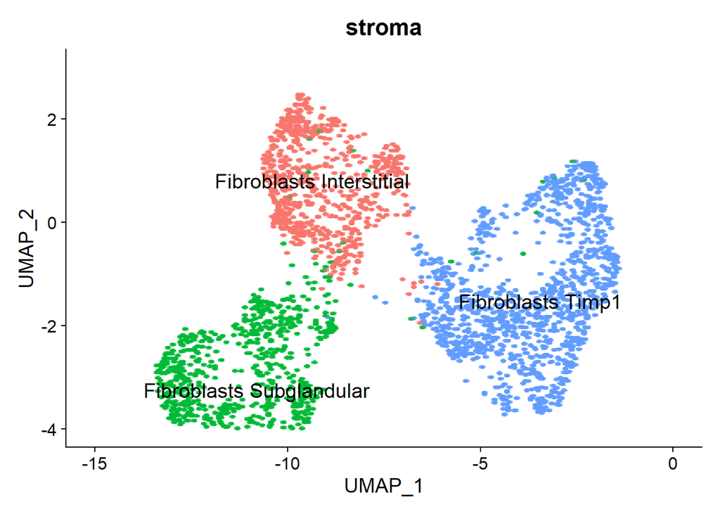

```r
mouse_seurat_stroma$pan_caf <- gsub(" Low", "", mouse_seurat_stroma$pan_caf)
mouse_seurat_stroma$pan_caf <- gsub("Low ", "", mouse_seurat_stroma$pan_caf)

Idents(mouse_seurat_stroma) <- "stroma"
fibroblast_seurat <- subset(mouse_seurat_stroma, idents = c("Fibroblasts Subglandular", "Fibroblasts Interstitial", "Fibroblasts Timp1"))



Idents(fibroblast_seurat) <- "pan_caf"
levels(fibroblast_seurat) <- c("Low", "Pan-iCAF", "Pan-dCAF", "Pan-pCAF",
                           "Pan-dCAF Pan-pCAF", "Pan-iCAF Pan-dCAF", "Pan-iCAF Pan-pCAF",
                           "Pan-iCAF Pan-dCAF Pan-pCAF")

UMAP_stroma <- DimPlot(fibroblast_seurat, group.by = "stroma", label = TRUE, repel = FALSE, label.size = 5, raster = TRUE, pt.size = 3) + NoLegend() + xlim (c(-15, 0)) + ylim(c(-4, 3))
UMAP_stroma
```

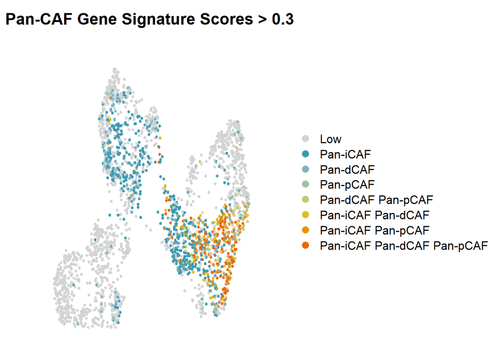

```r
pal8 <- wes_palette("Zissou1", 8, type = "continuous")
UMAP_CAF <- DimPlot(fibroblast_seurat, order = TRUE, cols = c("lightgrey", pal8), pt.size = 3, raster = TRUE) +
  ggtitle("Pan-CAF Gene Signature Scores > 0.3") +
  xlim (c(-15, 0)) + ylim(c(-4, 3)) +
  NoAxes()+
  theme(plot.title = element_text(hjust = 0.5))
UMAP_CAF
```

```r
table(fibroblast_seurat$pan_caf, fibroblast_seurat$stroma)
```

```
##
##                              Fibroblasts Interstitial Fibroblasts Subglandular
##   Low                                             420                      896
##   Pan-dCAF                                          1                        0
##   Pan-dCAF Pan-pCAF                                 1                        0
##   Pan-iCAF                                        271                       61
##   Pan-iCAF Pan-dCAF                                 3                        0
##   Pan-iCAF Pan-dCAF Pan-pCAF                        4                        0
##   Pan-iCAF Pan-pCAF                                 2                        0
##   Pan-pCAF                                          1                        0
##
##                              Fibroblasts Timp1
##   Low                                      546
##   Pan-dCAF                                  33
##   Pan-dCAF Pan-pCAF                         50
##   Pan-iCAF                                 283
##   Pan-iCAF Pan-dCAF                        131
##   Pan-iCAF Pan-dCAF Pan-pCAF               165
##   Pan-iCAF Pan-pCAF                          2
##   Pan-pCAF                                   7
```

# Correlation of macrophage and fibroblast fractions

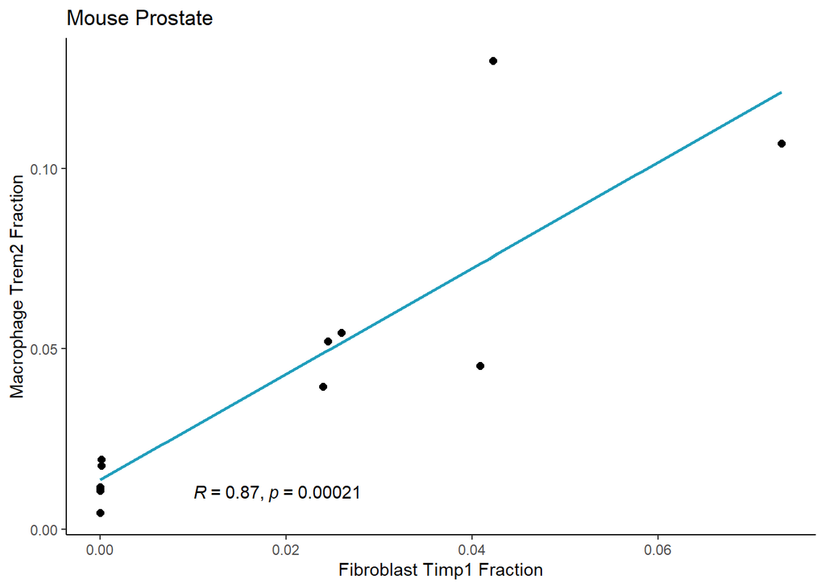

```r
stroma_combined_df <- readRDS(file = "stroma_combined_df.rds")
immune_combined_df <- readRDS(file = "immune_combined_df.rds")

stroma_df <- stroma_combined_df[, c("Cluster", "Library", "Fraction")] %>% na.omit()
immune_df <- immune_combined_df[, c("Cluster", "Library", "Fraction")] %>% na.omit()

merged_df <- merge(stroma_df, immune_df, by = "Library")
merged_df_filter <- merged_df %>% filter(Cluster.x == "Fibroblasts Timp1" & Cluster.y == "Macrophages Trem2")
colnames(merged_df_filter)[3] <- "Fibroblast Timp1 Fraction"
colnames(merged_df_filter)[5] <- "Macrophage Trem2 Fraction"

ggplot(merged_df_filter, aes(x=`Fibroblast Timp1 Fraction`, y= `Macrophage Trem2 Fraction`)) +
  geom_smooth(method=lm, se=FALSE, color = "#219ebc") +
  geom_point(size = 2) +
  stat_cor(method = "pearson", label.x = 0.01, label.y = 0.010) +
  theme_classic() +
  ggtitle("Mouse Prostate")
```